# GGPLOT2 plots library

```r
load("05 CLEANSED data sets nodups.RData")
```

#### SECION 01-03. STP. Linechart

First set the list of metrics to use in our plots, health indicators for STP displayed below:

```r
table(IMP_STP_NODUPS$Measure)
```

```
##
##                Cancers and Tumours (PBC 02) - Non-elective - Difference in admission rate (12 months to quarter end)
##                                                                                                                   88
##                                                   Cardiology - Echocardiography: Waiting list per 100,000 population
##                                                                                                                  372
##                  Cardiology (TFCs 320 and 321) - Outpatient - Difference in activity rate (12 months to quarter end)
##                                                                                                                   88
##       Spinal surgery service (TFC 108) - Outpatient - Percentage of patients discharged after their first attendance
##                                                                                                                  406
##                                                          Total: Percentage of waiting list patients waiting 6+ weeks
##                                                                                                                  374
##                                                                           Total: Waiting list per 100,000 population
##                                                                                                                  373
## Trauma & orthopaedics (TFCs 110 & 214) - Outpatient - Percentage of patients discharged after their first attendance
##                                                                                                                  407
##                            Trauma and Orthopaedic Service: Waiting list (incomplete pathways) per 100,000 population
##                                                                                                                  374
```

```r
  library(ggplot2)
  library(dplyr)
  Data_STP_PLOT1 <- IMP_STP_NODUPS %>%
    filter(Measure=="Cancers and Tumours (PBC 02) - Non-elective - Difference in admission rate (12 months to quarter end)")
  Data_STP_PLOT2 <- IMP_STP_NODUPS %>%
    filter(Measure=="Cardiology - Echocardiography: Waiting list per 100,000 population")
  Data_STP_PLOT3 <- IMP_STP_NODUPS %>%
    filter(Measure=="Cardiology (TFCs 320 and 321) - Outpatient - Difference in activity rate (12 months to quarter end)")
  Data_STP_PLOT4 <- IMP_STP_NODUPS %>%
    filter(Measure=="Spinal surgery service (TFC 108) - Outpatient - Percentage of patients discharged after their first attendance")
  Data_STP_PLOT5 <- IMP_STP_NODUPS %>%
    filter(Measure=="Total: Percentage of waiting list patients waiting 6+ weeks")

  Data_STP_PLOT6 <- IMP_STP_NODUPS %>%
    filter(Measure=="Total: Waiting list per 100,000 population")

Data_STP_PLOT7 <- IMP_STP_NODUPS %>%
    filter(Measure=="Trauma & orthopaedics (TFCs 110 & 214) - Outpatient - Percentage of patients discharged after their first attendance")
                                                                                                             Data_STP_PLOT8 <- IMP_STP_NODUPS %>%
    filter(Measure=="Trauma and Orthopaedic Service: Waiting list (incomplete pathways) per 100,000 population")
```

### 01. Standard line charts for one STP

```r
  PLOT01DATA <- IMP_STP_NODUPS %>%
                  select(Measure,OrgName,ReportingDate,Value) %>%
      filter(Measure=="Cancers and Tumours (PBC 02) - Non-elective - Difference in admission rate (12 months to quarter end)" &
            OrgName == "Birmingham and Solihull STP")
  PLOT01DATA
```

| Measure | OrgName | ReportingDate | Value |
| --- | --- | --- | --- |
| Cancers and Tumours (PBC 02) - Non-elective - Difference in admission rate (12 months to quarter end) | Birmingham and Solihull STP | 2021-09-30 | -18.61948 |
| Cancers and Tumours (PBC 02) - Non-elective - Difference in admission rate (12 months to quarter end) | Birmingham and Solihull STP | 2021-06-30 | -16.90640 |
| Cancers and Tumours (PBC 02) - Non-elective - Difference in admission rate (12 months to quarter end) | Birmingham and Solihull STP | 2021-03-31 | -19.43068 |
| Cancers and Tumours (PBC 02) - Non-elective - Difference in admission rate (12 months to quarter end) | Birmingham and Solihull STP | 2020-12-31 | -20.16882 |
| Cancers and Tumours (PBC 02) - Non-elective - Difference in admission rate (12 months to quarter end) | Birmingham and Solihull STP | 2020-09-30 | -24.13897 |
| Cancers and Tumours (PBC 02) - Non-elective - Difference in admission rate (12 months to quarter end) | Birmingham and Solihull STP | 2020-06-30 | -34.67608 |
| Cancers and Tumours (PBC 02) - Non-elective - Difference in admission rate (12 months to quarter end) | Birmingham and Solihull STP | 2020-03-31 | -43.72665 |
| Cancers and Tumours (PBC 02) - Non-elective - Difference in admission rate (12 months to quarter end) | Birmingham and Solihull STP | 2019-12-31 | -53.25076 |

Now that we have a subset of variables, we can produce a standard Line-chart

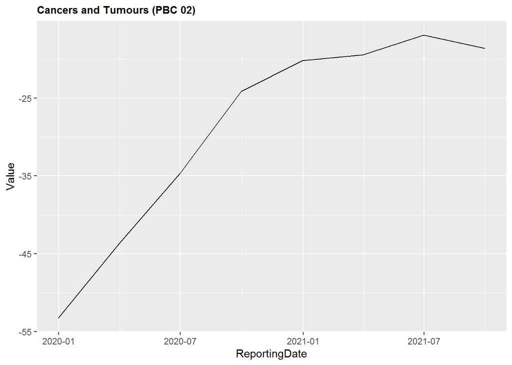

```r
 library(ggplot2)
  library(dplyr)
  PLOT01  <- PLOT01DATA %>%
    ggplot(aes(x = ReportingDate, y = Value)) +
    geom_line() +
    ggtitle("Cancers and Tumours (PBC 02)") +
    theme(plot.title = element_text(size = 10, face = "bold")) +
    theme(legend.position="none")
  PLOT01
```

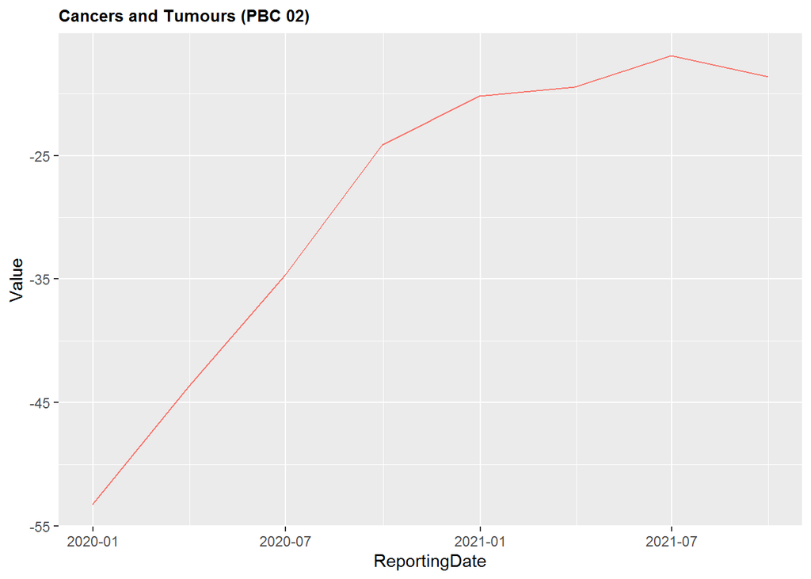

```r
 library(ggplot2)
  library(dplyr)
  PLOT03   <- PLOT01DATA %>%
    ggplot(aes(x = ReportingDate, y = Value)) +
    geom_line(aes(color = OrgName)) +
    ggtitle("Cancers and Tumours (PBC 02)") +
    theme(plot.title = element_text(size = 10, face = "bold")) +
    theme(legend.position="none")
  PLOT03
```

### 01. Facet wrap line_charts based on OrgName STP name

We use ggplot() package to produce a facetted line chart, in ggplot2 each line of the script build a new layer in the plot to obtain the final output.

The first command ggplot(aes(x = ReprtinDate, y= Value)), just provides the variables used for the x and y axis. We need to add an extra function geom_line() to be able to draw our first plot. If we wanted to combine a line chart alongside a dot one, we would only have to add geom_point() to the line below geom_line()

This demonstrates the building principle behind GGPLOT2, to combine all plots in a single image of facetted line_charts by STP, we then add the facet_wrap() function and we specify that we want to split the plots by STP, in this instance.

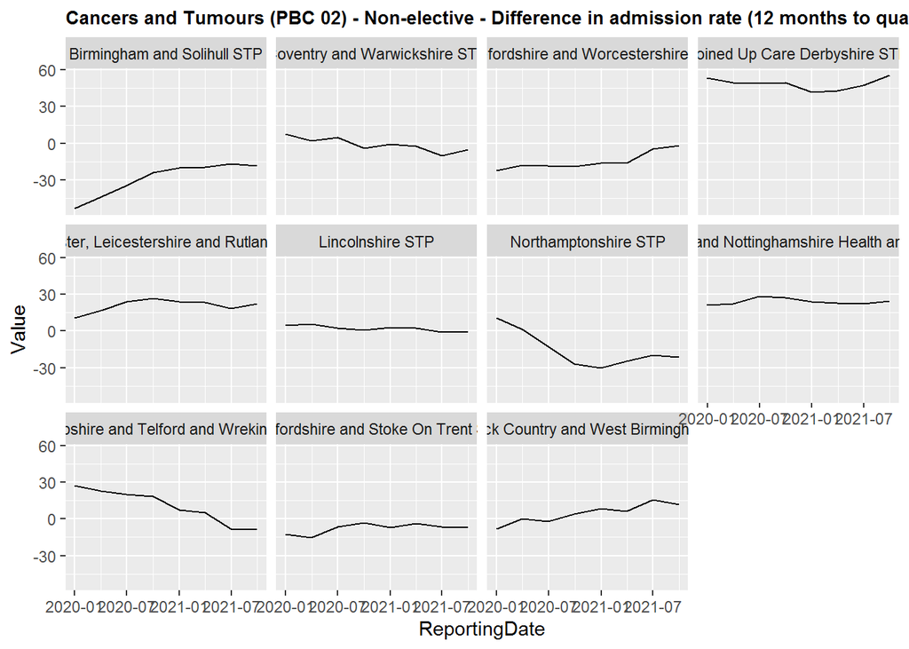

```r
# x = ReportingDate, y Value, facet_wrap (~OrgName)
 library(ggplot2)
  library(dplyr)
  PLOT04  <- Data_STP_PLOT1 %>%
    ggplot(aes(x = ReportingDate, y = Value)) +
    geom_line() +
    ggtitle("Cancers and Tumours (PBC 02) - Non-elective - Difference in admission rate (12 months to quarter end") +
    theme(plot.title = element_text(size = 10, face = "bold")) +
    facet_wrap(~OrgName) +
    theme(legend.position="none")
  PLOT04
```

```r
 # ggsave(paste0("01 Facet_wrap_geom_line_STP","_",format(Sys.time(),"%Y-%m-%d_%H-%M"),".jpeg"),
  ggsave(paste0("01 Facet_wrap_geom_line_STP","_",format(Sys.time(),"%Y-%m-%d"),".jpeg"),
       width = 30, height = 20, dpi = 150, units = "cm")
```

### 02.Include colour for each plot

We can include colour in the above plots, by adding color parameter to geom_line() object as in the script below

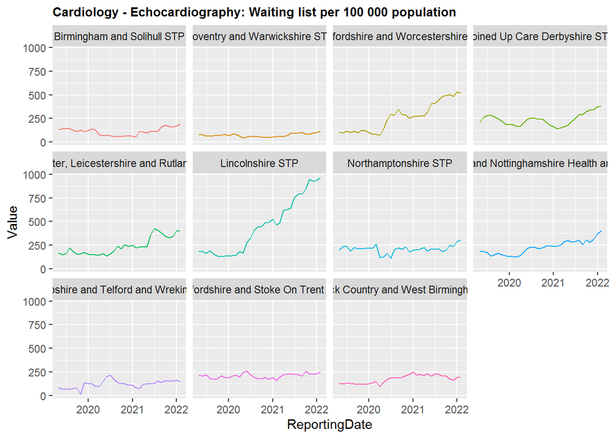

```r
# x = ReportingDate, y Value, facet_wrap (~OrgName)
 library(ggplot2)
  library(dplyr)
  PLOT04COLOR  <- Data_STP_PLOT2 %>%
                  ggplot(aes(x = ReportingDate, y = Value)) +
                  ggtitle("Cardiology - Echocardiography: Waiting list per 100 000 population") +
                  theme(plot.title = element_text(size = 10, face = "bold")) +
                  geom_line(aes(color = OrgName)) +
                  facet_wrap(~OrgName) +
                  theme(legend.position="none")
  PLOT04COLOR
```

```r
  ggsave(paste0("02 Facet_wrap_geom_line_STP_COLOUR","_",format(Sys.time(),"%Y-%m-%d"),".jpeg"),

       width = 30, height = 20, dpi = 150, units = "cm")
```

### 03.Reduce Main plot Title size

We can tidy up the titles in the STP individual plots to make them fit on the same plot area

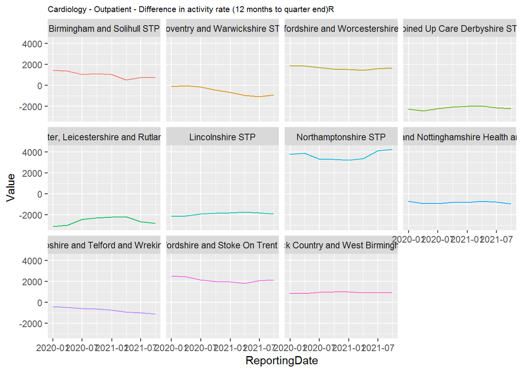

```r
# x = ReportingDate, y Value, facet_wrap (~OrgName)
 library(ggplot2)
  library(dplyr)
  PLOT05  <- Data_STP_PLOT3 %>%
    ggplot(aes(x = ReportingDate, y = Value)) +
    ggtitle("Cardiology - Outpatient - Difference in activity rate (12 months to quarter end)R") +
    theme(plot.title = element_text(size = 8, face = "plain")) +
    geom_line(aes(color = OrgName)) +
    facet_wrap(~OrgName) +
    theme(legend.position="none")
  PLOT05
```

```r
  ggsave(paste0("03 Facet_wrap_geom_line_STP_Title","_",format(Sys.time(),"%Y-%m-%d"),".jpeg"),
       width = 30, height = 20, dpi = 150, units = "cm")
```

### 04.Wrap up STP titles for each plot in two lines

We can use labeller() function to display STP individual plot titles in two lines to avoid truncation: facet_wrap(~Orgname, labeller = label_wrap_gen(width = 20)) amd alsp we remove legend from plot using theme(legend.position = “none”)

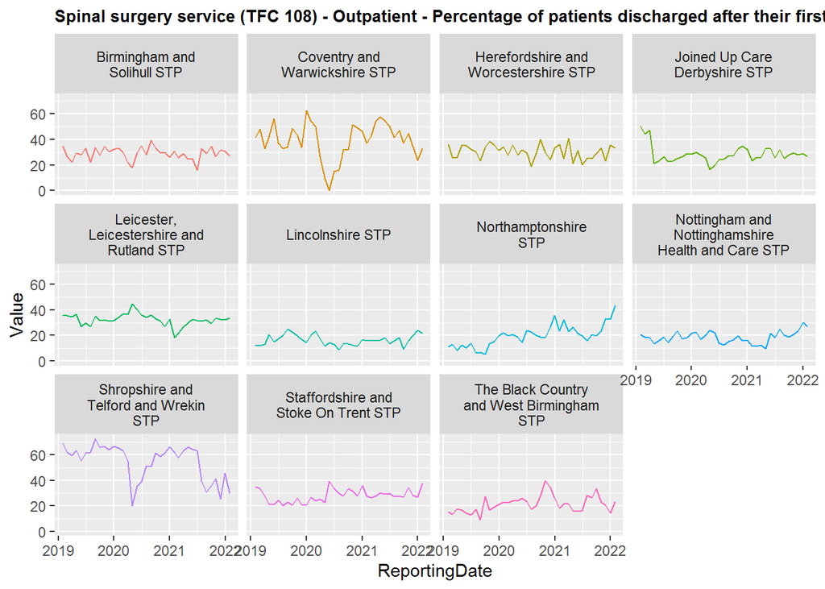

```r
# x = ReportingDate, y Value, facet_wrap (~OrgName)
 library(ggplot2)
  library(dplyr)
  PLOT06  <- Data_STP_PLOT4 %>%
    ggplot(aes(x = ReportingDate, y = Value)) +
    ggtitle("Spinal surgery service (TFC 108) - Outpatient - Percentage of patients discharged after their first attendance") +
    theme(plot.title = element_text(size = 10, face = "bold")) +
       geom_line(aes(color = OrgName)) +
    # Facet wrap_titles_in two lines
    facet_wrap(~OrgName, labeller = label_wrap_gen(width = 20)) +
    theme(legend.position="none")
  PLOT06
```

```r
  ggsave(paste0("04 Facet_wrap_geom_line_title_wrap","_",format(Sys.time(),"%Y-%m-%d"),".jpeg"),
       width = 30, height = 20, dpi = 150, units = "cm")
```